# Project #2

# cart (James Adler)

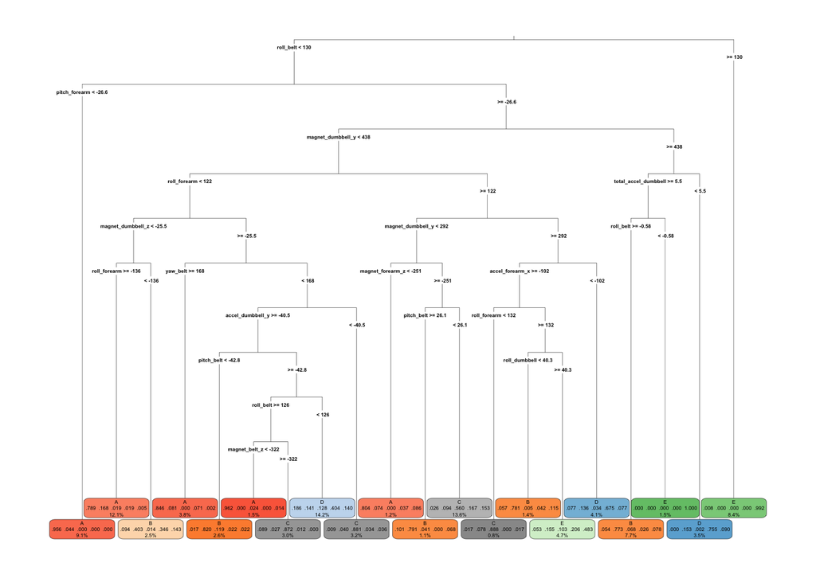

```r
#creating cart model
set.seed(117)
james_tree <- rpart(classe ~. ,data = part_training, method = "class")
#gets the optimal cp (cp with minimum erro)
optimal_cp<-james_tree$cptable[which.min(james_tree$cptable[,"xerror"]),"CP"]
#uses optimal cp to create new tree
james_ptree<-prune(james_tree,optimal_cp)
#viewing new tree
rpart.plot(james_ptree,type = 3,digits = 3, fallen.leaves = TRUE)
```

```r
#runs new pruned tree model with partitioned test data
james_pred<-predict(james_ptree, part_test, type="class")
confusionMatrix(james_pred,part_test$classe)
```

```
## Confusion Matrix and Statistics
##
##           Reference
## Prediction    A    B    C    D    E
##          A 1355  171   19   37   14
##          B   60  626   47   72   88
##          C   41   91  823  165  132
##          D  169  202  119  663  161
##          E   19   58   15   52  688
##
## Overall Statistics
##
##                Accuracy : 0.7058
##                  95% CI : (0.694, 0.7174)
##     No Information Rate : 0.2793
##     P-Value [Acc > NIR] : < 2.2e-16
##
##                   Kappa : 0.6296
##  Mcnemar's Test P-Value : < 2.2e-16
##
## Statistics by Class:
##
##                      Class: A Class: B Class: C Class: D Class: E
## Sensitivity            0.8242   0.5453   0.8045   0.6704   0.6353
## Specificity            0.9432   0.9437   0.9118   0.8671   0.9700
## Pos Pred Value         0.8490   0.7010   0.6573   0.5046   0.8269
## Neg Pred Value         0.9326   0.8955   0.9569   0.9287   0.9219
## Prevalence             0.2793   0.1950   0.1738   0.1680   0.1840
## Detection Rate         0.2302   0.1063   0.1398   0.1126   0.1169
## Detection Prevalence   0.2711   0.1517   0.2127   0.2232   0.1413
## Balanced Accuracy      0.8837   0.7445   0.8581   0.7687   0.8026
```

```r
#tests our algorithm on the 20 outputless observations
james_final_prediction<-predict(james_ptree,test_final)
james_final_prediction
```

```
##             A          B           C          D           E
## 1  0.10135135 0.79054054 0.040540541 0.00000000 0.067567568
## 2  0.78915663 0.16807229 0.019277108 0.01867470 0.004819277
## 3  0.95592949 0.04407051 0.000000000 0.00000000 0.000000000
## 4  0.18647541 0.14139344 0.128073770 0.40368852 0.140368852
## 5  0.18647541 0.14139344 0.128073770 0.40368852 0.140368852
## 6  0.02616124 0.09396690 0.560064068 0.16657768 0.153230112
## 7  0.07719928 0.13644524 0.034111311 0.67504488 0.077199282
## 8  0.18647541 0.14139344 0.128073770 0.40368852 0.140368852
## 9  0.95592949 0.04407051 0.000000000 0.00000000 0.000000000
## 10 0.78915663 0.16807229 0.019277108 0.01867470 0.004819277
## 11 0.02616124 0.09396690 0.560064068 0.16657768 0.153230112
## 12 0.05312500 0.15468750 0.103125000 0.20625000 0.482812500
## 13 0.02616124 0.09396690 0.560064068 0.16657768 0.153230112
## 14 0.95592949 0.04407051 0.000000000 0.00000000 0.000000000
## 15 0.05312500 0.15468750 0.103125000 0.20625000 0.482812500
## 16 0.18647541 0.14139344 0.128073770 0.40368852 0.140368852
## 17 0.96153846 0.00000000 0.024038462 0.00000000 0.014423077
## 18 0.09428571 0.40285714 0.014285714 0.34571429 0.142857143
## 19 0.09428571 0.40285714 0.014285714 0.34571429 0.142857143
## 20 0.05729167 0.78125000 0.005208333 0.04166667 0.114583333
```

# Random forest variation with regularization of data (Nikki)

```r
set.seed(1234)
x <- subset(part_training, select=-classe)
y <- part_training$classe
bestmtry <- tuneRF(x, y, stepFactor = 1.5, improve=1e-5, ntree=500)
```

```
## mtry = 7  OOB error = 0.59%
## Searching left ...
## mtry = 5     OOB error = 0.58%
## 0.01234568 1e-05
## mtry = 4     OOB error = 0.6%
## -0.025 1e-05
## Searching right ...
## mtry = 10    OOB error = 0.5%
## 0.1375 1e-05
## mtry = 15    OOB error = 0.52%
## -0.04347826 1e-05
```

[figure not shown]

```r
print(bestmtry)
```

```
##        mtry    OOBError
## 4.OOB     4 0.005970149
## 5.OOB     5 0.005824536
## 7.OOB     7 0.005897343
## 10.OOB   10 0.005023662
## 15.OOB   15 0.005242082
```

```r
nikki_rf <- randomForest(classe~., data=part_training, ntree=300, mtry=10, importance=TRUE)
nikki_pred <- predict(nikki_rf, part_test)
nikki_pred
```

[output not shown]

[output cut: 928 more lines]

[output not shown]

```r
confusionMatrix(nikki_pred, part_test$classe, dnn=c("prediction","reference"))
```

```
## Confusion Matrix and Statistics
##
##           reference
## prediction    A    B    C    D    E
##          A 1641   13    0    0    0
##          B    1 1133    9    0    0
##          C    2    2 1011   12    0
##          D    0    0    3  977    3
##          E    0    0    0    0 1080
##
## Overall Statistics
##
##                Accuracy : 0.9924
##                  95% CI : (0.9898, 0.9944)
##     No Information Rate : 0.2793
##     P-Value [Acc > NIR] : < 2.2e-16
##
##                   Kappa : 0.9903
##  Mcnemar's Test P-Value : NA
##
## Statistics by Class:
##
##                      Class: A Class: B Class: C Class: D Class: E
## Sensitivity            0.9982   0.9869   0.9883   0.9879   0.9972
## Specificity            0.9969   0.9979   0.9967   0.9988   1.0000
## Pos Pred Value         0.9921   0.9913   0.9844   0.9939   1.0000
## Neg Pred Value         0.9993   0.9968   0.9975   0.9976   0.9994
## Prevalence             0.2793   0.1950   0.1738   0.1680   0.1840
## Detection Rate         0.2787   0.1925   0.1717   0.1660   0.1835
## Detection Prevalence   0.2810   0.1942   0.1745   0.1670   0.1835
## Balanced Accuracy      0.9976   0.9924   0.9925   0.9933   0.9986
```

```r
# Run final prediction
nikki_finalpred <- predict(nikki_rf, test_final)
nikki_finalpred
```

```
##  1  2  3  4  5  6  7  8  9 10 11 12 13 14 15 16 17 18 19 20
##  B  A  B  A  A  E  D  B  A  A  B  C  B  A  E  E  A  B  B  B
## Levels: A B C D E
```

# Support Vector Machine by Stefan (we attempted to tune it but the accuracy only minorly improved and it was quite time consuming)

```r
stefan_svm <- svm(classe ~. ,data = part_training)
stefan_pred<- predict(stefan_svm, part_test)
confusionMatrix(stefan_pred,part_test$classe, dnn=c("prediction","reference"))
```

```
## Confusion Matrix and Statistics
##
##           reference
## prediction    A    B    C    D    E
##          A 1634  103    2    1    2
##          B    3 1014   35    0    3
##          C    6   23  977  114   31
##          D    0    4    8  872   43
##          E    1    4    1    2 1004
##
## Overall Statistics
##
##                Accuracy : 0.9344
##                  95% CI : (0.9278, 0.9406)
##     No Information Rate : 0.2793
##     P-Value [Acc > NIR] : < 2.2e-16
##
##                   Kappa : 0.917
##  Mcnemar's Test P-Value : < 2.2e-16
##
## Statistics by Class:
##
##                      Class: A Class: B Class: C Class: D Class: E
## Sensitivity            0.9939   0.8833   0.9550   0.8817   0.9271
## Specificity            0.9745   0.9913   0.9642   0.9888   0.9983
## Pos Pred Value         0.9380   0.9611   0.8488   0.9407   0.9921
## Neg Pred Value         0.9976   0.9723   0.9903   0.9764   0.9838
## Prevalence             0.2793   0.1950   0.1738   0.1680   0.1840
## Detection Rate         0.2776   0.1722   0.1660   0.1481   0.1705
## Detection Prevalence   0.2959   0.1792   0.1955   0.1575   0.1719
## Balanced Accuracy      0.9842   0.9373   0.9596   0.9352   0.9627
```

# This is Stefan’s neural network, it wouldn’t run so we left it commented out

scaledata<-scale(train_final[,1:52]) #scale normalization

normalize <- function(x) { return ((x - min(x)) / (max(x) - min(x))) }#max-min normalization

maxmindf<-as.data.frame(lapply(scaledata, normalize))#normilization takes too much computing power

test_final_2<-cbind(maxmindf,class.ind(train_final$classe))

# partitions 70% of data into training set

trainingRowIndex<-sample(1:nrow(train_final2), size = .7*nrow(train_final2)) trainset<-train_final2[trainingRowIndex, ]

# leaves 30% for testing and validating

testset<-train_final2[-trainingRowIndex, ]

# Test the resulting output

temp_test <- subset(testset, select = c(“roll_belt”,“pitch_belt”, “yaw_belt”,“total_accel_belt”,“gyros_belt_x”,“gyros_belt_y”,“gyros_belt_z”,“accel_belt_x”,“accel_belt_y”,“accel_belt_z”,“magnet_belt_x”,“magnet_belt_y”,“magnet_belt_z”,“roll_arm”,“pitch_arm”,“yaw_arm”,“total_accel_arm”,“gyros_arm_x”,“gyros_arm_y”,“gyros_arm_z”,“accel_arm_x”,“accel_arm_y”,“accel_arm_z”,“magnet_arm_x”,“magnet_arm_y”,“magnet_arm_z”,“roll_dumbbell”,“pitch_dumbbell”,“yaw_dumbbell”,“total_accel_dumbbell”,“gyros_dumbbell_x”,“gyros_dumbbell_y”,“gyros_dumbbell_z”,“accel_dumbbell_x”,“accel_dumbbell_y”,“accel_dumbbell_z”,“magnet_dumbbell_x”,“magnet_dumbbell_y”,“magnet_dumbbell_z”,“roll_forearm”,“pitch_forearm”,“yaw_forearm”,“total_accel_forearm”,“gyros_forearm_x”,“gyros_forearm_y”,“gyros_forearm_z”,“accel_forearm_x”,“accel_forearm_y”,“accel_forearm_z”,“magnet_forearm_x”,“magnet_forearm_y”,“magnet_forearm_z”))

head(temp_test)

nn.results <- compute(nn, temp_test)

# Accuracy

results <- data.frame(actual = testset(“A”,“B”,“C”,“D”,“E”), prediction = nn.results$net.result)